# Analisi del mondo del lavoro IT

Vincenzo Carlino

22/8/2020

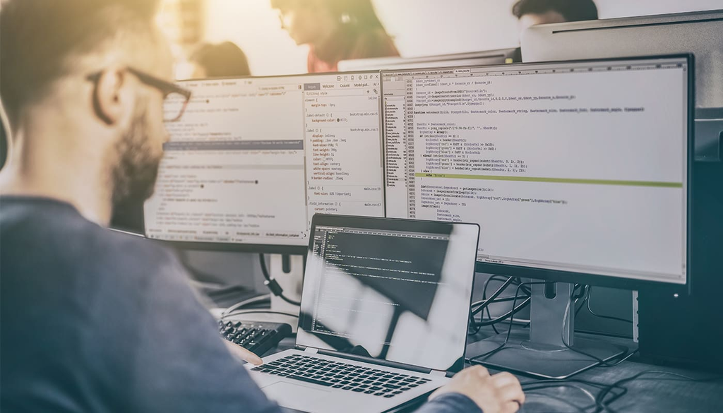

> **You can never understand everything. But, you should push yourself to understand the system.**  
> *- Ryan Dahl (Creator of Node JS)*

# Scopo

Il mondo del lavoro, un argomento che prima o poi, riguarderà ognuno di noi, chi prima chi poi. Io da studente lavoratore, sono già immerso in questo universo, e devo ammettere che fino ad oggi il mio panorama era molto ristretto. Lo scopo di questa analisi è fornire risposte a domande che potrebbero essere utili per il nostro futuro.

# Quali sono le città che offrono più opportunità?

Mi raccomando, fate il biglietto con l’assicurazione di rimborso…

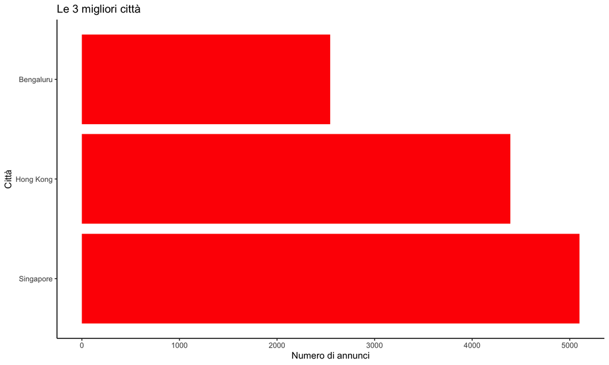

# E se io voglio lavorare come: data analyst?

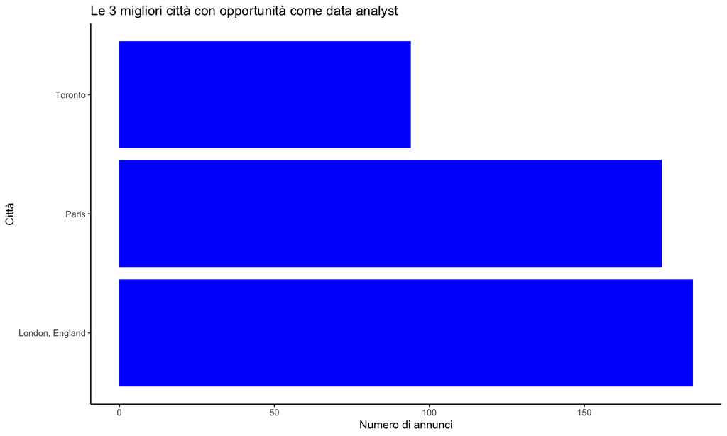

# Quali aziende offrono più opportunità?

Spoiler: Amazon

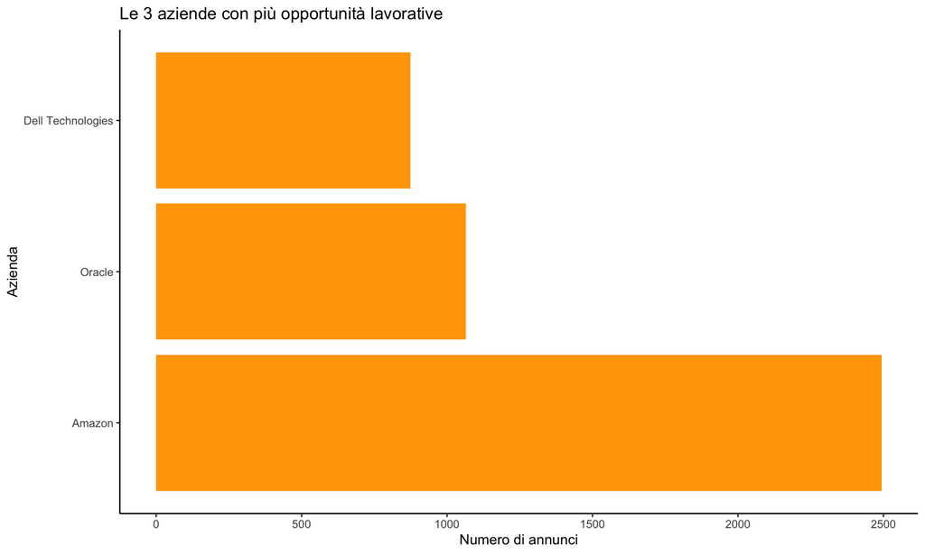

# E come data analyst?

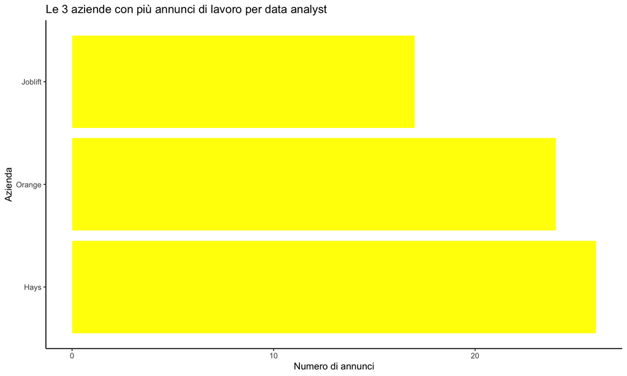

# Dal 1900 ad oggi, qual’è la decade che ha visto nascere più aziende?

E pensare che doveva finire il mondo, invece…

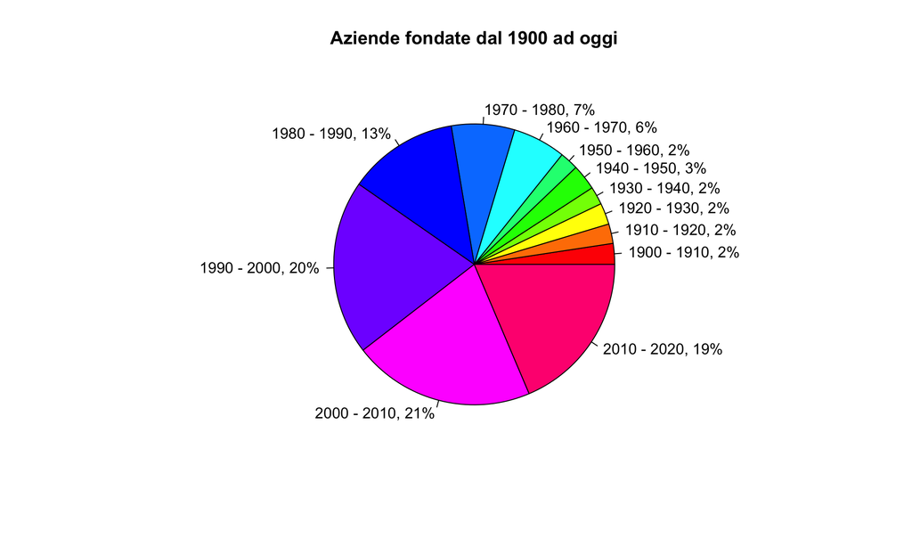

# Settori di punta?

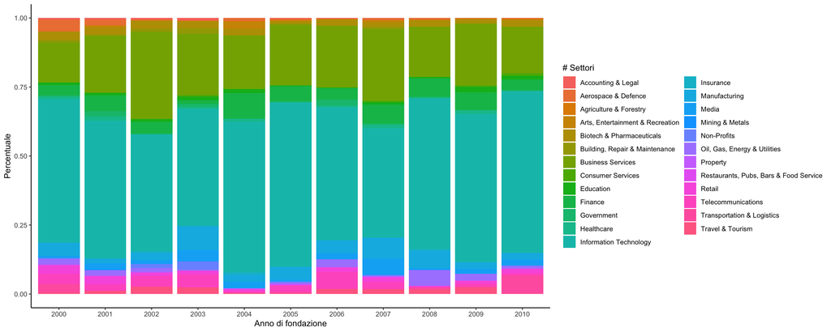

# Quindi l’IT vince, vediamo quali città hanno spinto maggiormente in questo settore

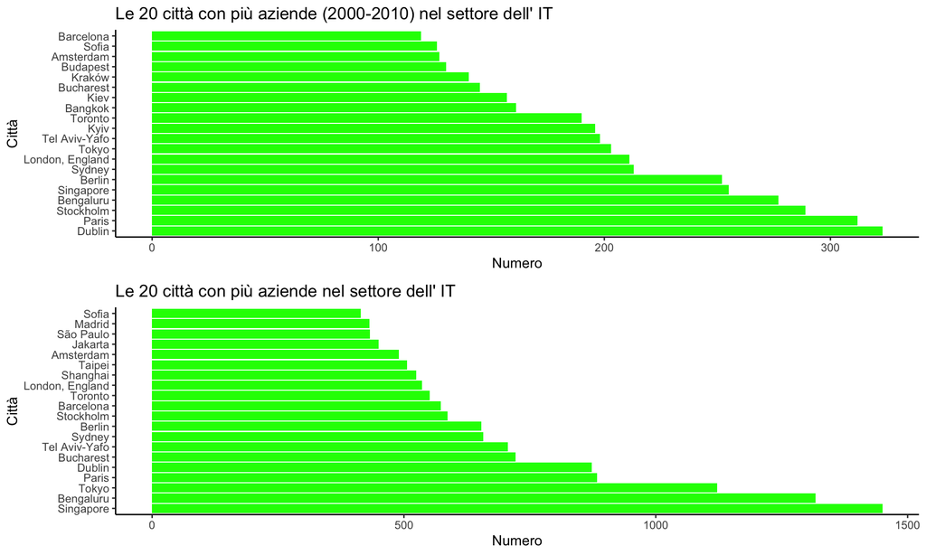

# La dimensione di un’azienda dipende dalla sua tipologia?

In base al tipo di azienda, vediamo se troveremo facilmente parcheggio

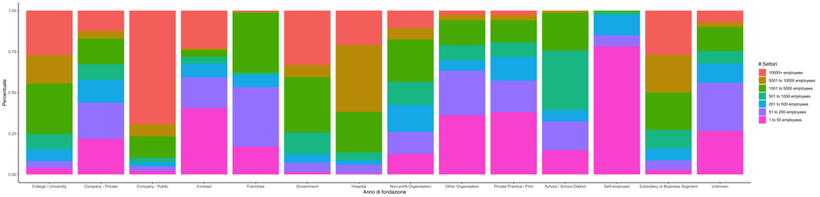

# Inghilterra

[figure not shown]

# Dal 1900 ad oggi, qual’è l’anno che ha visto nascere più aziende?

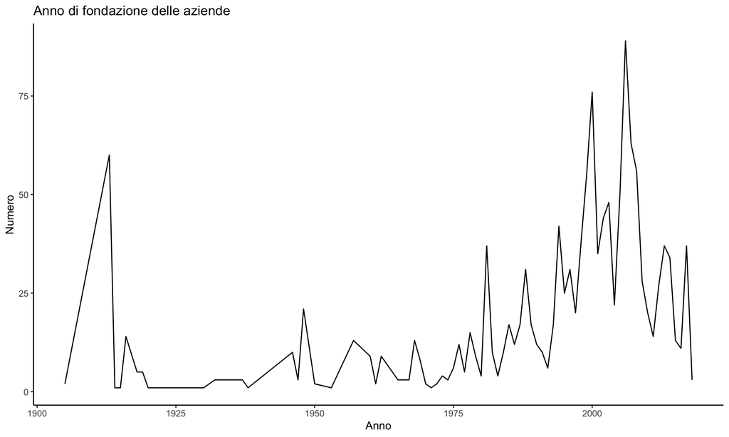

# Che settori spiccavano nel 2006?

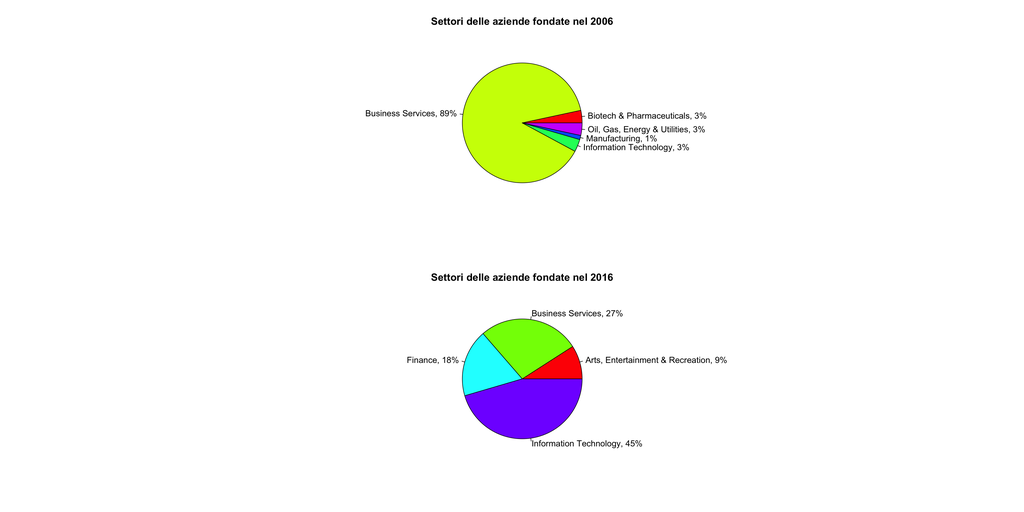

# Se voglio lavorare come data analyst, in che settore mi conviene di più?

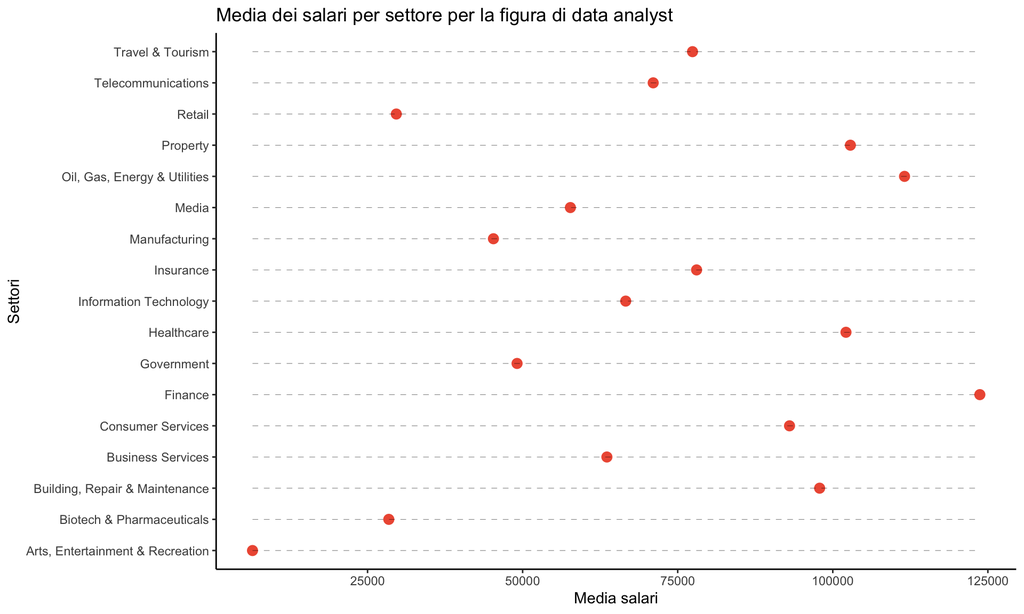

# Se voglio lavorare come programmatore, che linguaggio è più reddittizio?

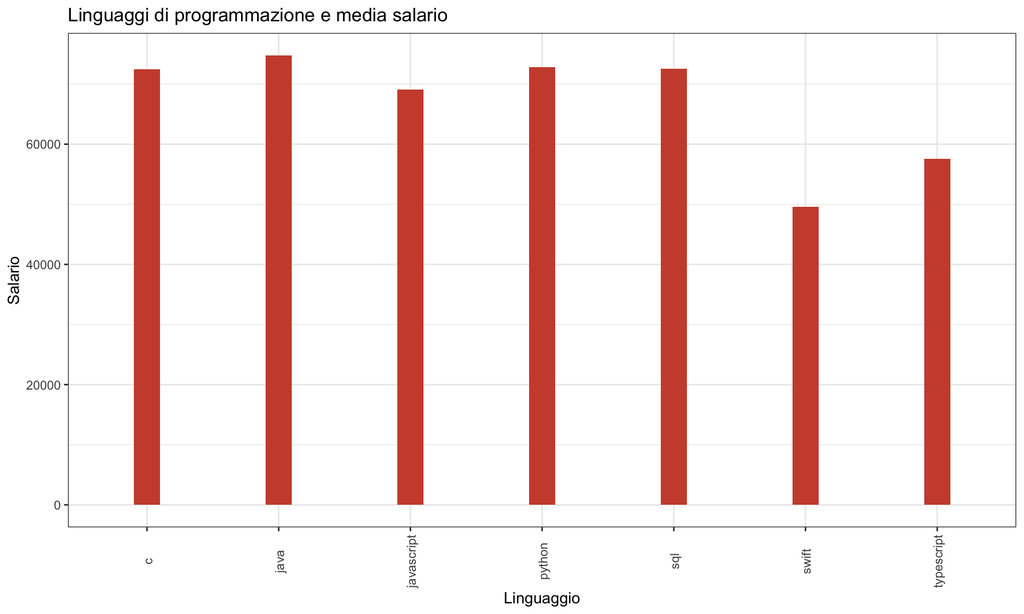

# Quanto contano i soldi? O i benefits?

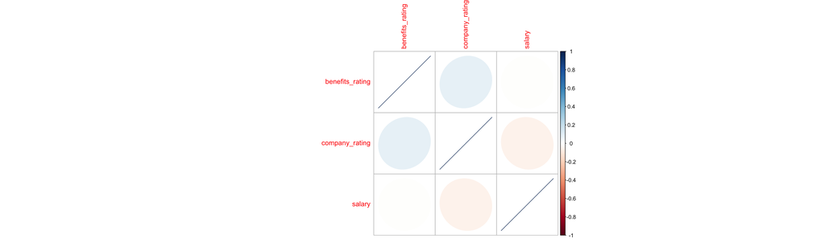

|  | benefits_rating | company_rating | salary |
| --- | --- | --- | --- |
| benefits_rating | 1.0000000 | 0.0833813 | -0.0031264 |
| company_rating | 0.0833813 | 1.0000000 | -0.0599849 |
| salary | -0.0031264 | -0.0599849 | 1.0000000 |

# Frequenza dei termini per benefit

Basso benefits rating

| word |
| --- |
| eacute |
| life |
| great |
| health |
| support |
| diverse |

Medio benefits rating

| word |
| --- |
| benefits |
| flexible |
| insurance |
| life |
| employees |
| work |

Alto benefits rating

| word |
| --- |
| benefits |
| employees |
| work |
| life |
| span |
| offer |